# Quentin Tarantino Movies

Caroline Hartley, Philipp Kouterguine

2024-11-11

## Libraries

```r
library(tidyverse)
```

```r
library(lubridate)
library(dplyr)
library(ggplot2)

options(repos = c(CRAN = "https://cran.rstudio.com/"))
install.packages("wordcloud")
library(wordcloud)
install.packages("RColorBrewer")
library(RColorBrewer)
install.packages("tm")
library(tm)
```

## Summary

##Purpose

The primary goal of our project was to analyze all death scenes and instances of characters swearing in Quentin Tarantino’s movies. A benefit of this is giving parents and organizations a clearer understanding of the films more mature content. Without prior knowledge, viewers might not know whether or not a movie contains slurs, how frequently they occur, or the extent of violent deaths known. Our database of of death sand swear words address this gap by ranking Tarantino’s films based on their combined counts of slurs and deaths.

Additionally, we were able to explore our interests in films and cinema while deepening our proficiency in R. To showcase our findings, we created a variety of plots and other visualizations. They are shown in the document below.

## Data

### Dictionary

- **Movie:** The Movie variable describes what movie an event came from. It is a categorical variable. This variable is important to the rest of the data because it is what connects the other variables.
- **Type:** The Type variable is a categorical variable that describes whether the event taking place is a swear word or a death.
- **Word:** The Word variable is a categorical variable that tells the swear word said if the event was a swear word. If the event was a death and not a word, the space is left blank.
- **Minutes_in:** The variable Minutes_in is a numerical variable. It list the time stamp in the movie that the event took place in the format “minutes.seconds.”

### Summary Statistics

```r
tarantino <- read.csv("tarantino.csv")
view(tarantino)
```

```r
summary(tarantino)
```

```
##     movie               type               word             minutes_in
##  Length:1894        Length:1894        Length:1894        Min.   :  0.40
##  Class :character   Class :character   Class :character   1st Qu.: 29.66
##  Mode  :character   Mode  :character   Mode  :character   Median : 70.53
##                                                           Mean   : 71.53
##                                                           3rd Qu.:112.83
##                                                           Max.   :160.45
```

The most information we can gather from the initial summary is from the minutes_in variable, which will be explored more below.

### NAs

There are empty cells in this data. The sum(is.na()) function shows 0 NAs, but this data has empty cells. The empty cells happen in the Word variable whenever it lines up with a death in the Type variable. Looking at the amount of deaths shown in the Type section above, we can determine that there is 190 empty spaces in the data. Because this projects specific explorations are unaffected by these blank spaces, we have not moved to replace them.

##Exploratory Data Analysis ### Movie

```r
movie_count <- tarantino %>%
  count(movie)
print(movie_count)
```

```
##                 movie   n
## 1    Django Unchained 309
## 2 Inglorious Basterds 106
## 3        Jackie Brown 372
## 4   Kill Bill: Vol. 1 120
## 5   Kill Bill: Vol. 2  80
## 6        Pulp Fiction 476
## 7      Reservoir Dogs 431
```

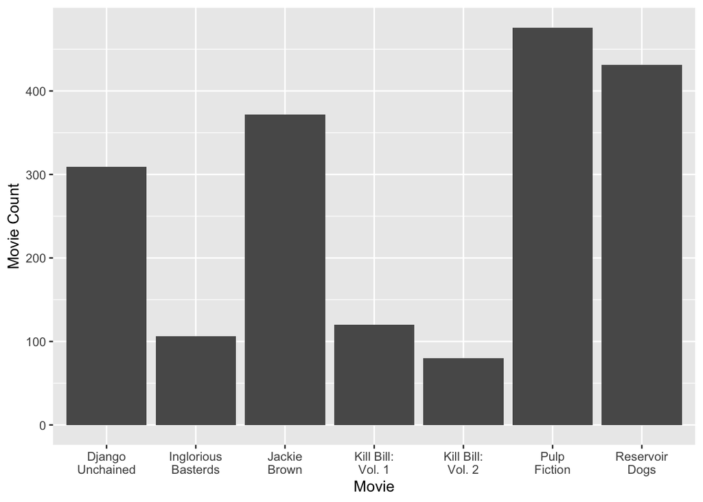

```r
movie_count <- movie_count %>%
  mutate(wrapped = str_wrap(movie, width = 10))

ggplot(movie_count, aes(x = wrapped, y = n)) +
  geom_bar(stat = "identity") +
  labs(x = "Movie", y = "Movie Count")
```

The table and bar chart above show the amount of times a certain movie is listed throughout the data set. Pulp Fiction had the most amount of events, followed by Reservoir Dogs. The movie with the least amount of events, swear words, or deaths, is Kill Bill Vol. 2. The ‘n’ column in the table represents the ‘Movie Count’ y-variable in the bar chart.

### Type

```r
type_count <- tarantino %>%
  count(type)
print(type_count)
```

```
##    type    n
## 1 death  190
## 2  word 1704
```

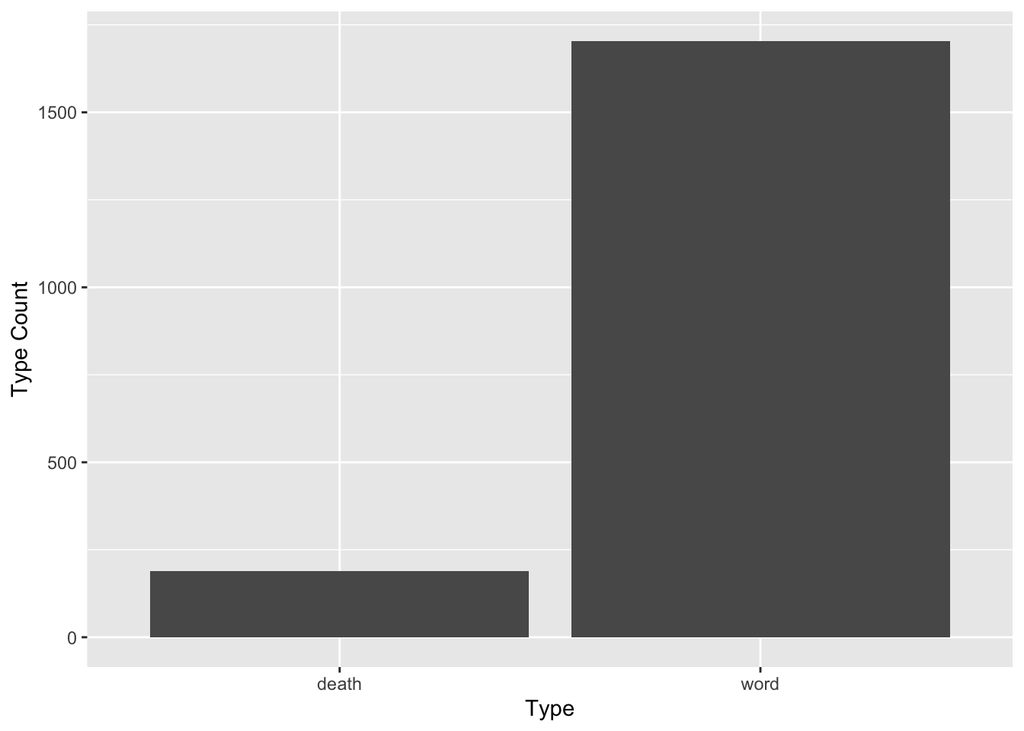

```r
ggplot(type_count, aes(x = type, y = n)) +
  geom_bar(stat = "identity") +
  labs(x = "Type", y = "Type Count")
```

The table and bar chart above show the differences in amount of deaths in movies and the amount of swears said in movies.

```r
type_count2 <- tarantino %>%
  count(movie, type)%>%
  mutate(movie_wrap = str_wrap(movie, width = 8))
print(type_count2)
```

```
##                  movie  type   n           movie_wrap
## 1     Django Unchained death  47    Django\nUnchained
## 2     Django Unchained  word 262    Django\nUnchained
## 3  Inglorious Basterds death  48 Inglorious\nBasterds
## 4  Inglorious Basterds  word  58 Inglorious\nBasterds
## 5         Jackie Brown death   4        Jackie\nBrown
## 6         Jackie Brown  word 368        Jackie\nBrown
## 7    Kill Bill: Vol. 1 death  63  Kill\nBill:\nVol. 1
## 8    Kill Bill: Vol. 1  word  57  Kill\nBill:\nVol. 1
## 9    Kill Bill: Vol. 2 death  11  Kill\nBill:\nVol. 2
## 10   Kill Bill: Vol. 2  word  69  Kill\nBill:\nVol. 2
## 11        Pulp Fiction death   7        Pulp\nFiction
## 12        Pulp Fiction  word 469        Pulp\nFiction
## 13      Reservoir Dogs death  10      Reservoir\nDogs
## 14      Reservoir Dogs  word 421      Reservoir\nDogs
```

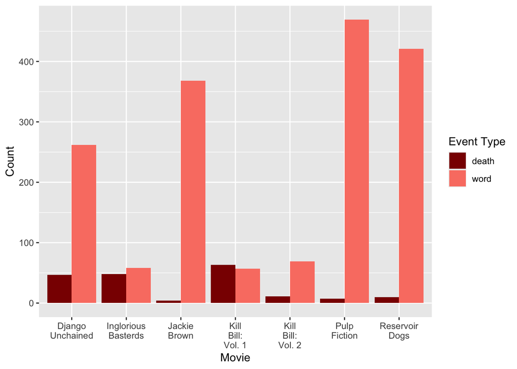

```r
ggplot(type_count2, aes(x = movie_wrap, y = n, fill = type)) +
  geom_bar(stat = "identity", position = "dodge") +
  labs(x = "Movie", y = "Count", fill = "Event Type")+
  scale_fill_manual(values = c("death" = "darkred", "word" = "salmon"))
```

This bar chart represents the amount of death and swear word occurrences that happened in each movie. In most movies, there are much more swear word occurrences than there is deaths. Outliers of this norm include Inglorious Bastards and Kill Bill: Vol. 1.

### Word

```r
word_count <- tarantino %>%
  count(word)
print(word_count)
```

```
##             word   n
## 1                190
## 2            ass 140
## 3          asses   4
## 4        asshead   1
## 5        asshole  10
## 6       assholes   5
## 7        bastard  10
## 8       bastards   1
## 9          bitch  64
## 10       bitches   9
## 11      bullshit  15
## 12   chickenshit   1
## 13  cockblockery   1
## 14    cocksucker   2
```

[output cut: 47 more lines]

**Data Cleanliness**

This table represents the amount of times each swear word is said throughout all of the movies. One thing that we noticed with this variable is that it is unorganized. It would be easier to understand the data given if it wasn’t so specific - many of the words are separated into present, past, and plural versions of themselves when they all mean the same thing in this scenario. To change this would streamline the data much more.

```r
text <- tarantino$word #First we make sure that the vector with all the words is being manipulated with.
tarantino_corpus <- Corpus(VectorSource(text)) #With that vector, we create a corpus. Why? Because it's easy.
#According to many sources, it's an easy way to manipulate copious amounts of text data.
tarantino_corpus <- tm_map(tarantino_corpus, content_transformer(tolower))
tarantino_corpus <- tm_map(tarantino_corpus, removePunctuation)
tarantino_corpus <- tm_map(tarantino_corpus, removeNumbers)
tarantino_corpus <- tm_map(tarantino_corpus, removeWords, stopwords("en"))
tarantino_corpus <- tm_map(tarantino_corpus, stripWhitespace)
```

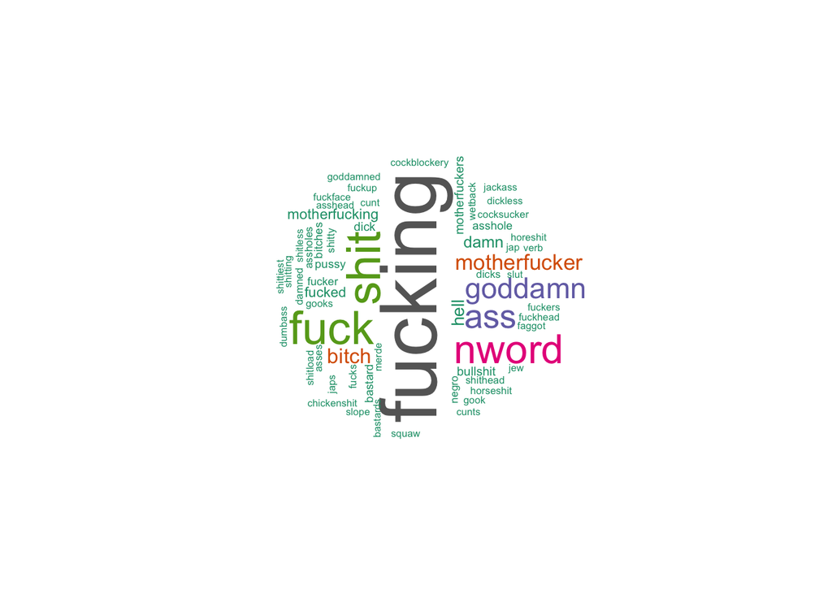

```r
#We change it all up a bit, make the text lowercase, remove punctuation etc. Simply cleaning it all up.

tarantino_tdm <- TermDocumentMatrix(tarantino_corpus) #Turn it into a giant matrix.
#A matrix is just like a dataframe, but it can only store 1 data type. In our case, it would be characters.
matrix <- as.matrix(tarantino_tdm)
word_freqs <- sort(rowSums(matrix), decreasing = TRUE) #For each word, we sum up all of the instances, and then make it in the decreasing order, with the sort() function.

word_data <- data.frame ( #Turn it into a data frame by combining the matrix with the word frequency list.
  word = names(word_freqs),
  freq = word_freqs
)

set.seed(1234) #And finally, we do the wordcloud.
wordcloud(words = word_data$word, freq = word_data$freq, min.freq = 1,
          max.words = 100, random.order = FALSE, rot.per = 0.35,
          colors = brewer.pal(8, "Dark2"))
```

We’ve been working on some new cool features that haven’t been studied in class yet, such as the word cloud. It’s a ball of words, and the more frequent the words are in the dataset, the bigger they get.

### Minutes_in

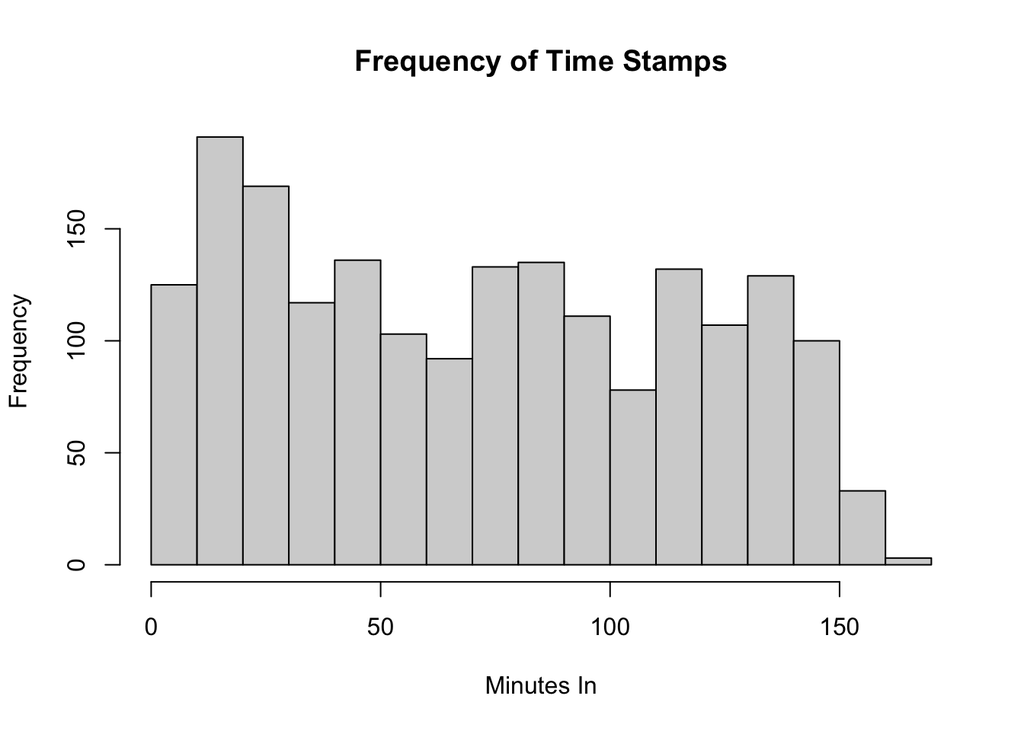

```r
hist(tarantino$minutes_in, main = "Frequency of Time Stamps", xlab = "Minutes In")
```

### Movie Length

```r
movie_length_minutes <- data.frame(
  movie = c("Reservoir Dogs", "Pulp Fiction", "Kill Bill: Vol. 1", "Kill Bill: Vol. 2",
            "Inglorious Basterds", "Django Unchained", "Jackie Brown"),
  length = c(99, 149, 111, 137, 153, 165, 160)
)

new_movie <- data.frame(
  movie = c("Reservoir Dogs", "Pulp Fiction", "Django Unchained", "Pulp Fiction", "Reservoir Dogs"),
  word = c("dick", "fucked", "shit", "bullshit", "dick"),
  time = c(0.40, 0.61, 1.43, 0.90, 1.75)
)

new_movie <- merge(new_movie, movie_length_minutes, by = "movie", all.x = TRUE)

new_movie$hours <- floor(new_movie$length / 60)
new_movie$minutes <- round(new_movie$length %% 60)

new_movie$duration <- paste(new_movie$hours, "hr", new_movie$minutes, "min")
```

```r
display <- new_movie %>%
  select(movie, duration)
display
```

```
##              movie    duration
## 1 Django Unchained 2 hr 45 min
## 2     Pulp Fiction 2 hr 29 min
## 3     Pulp Fiction 2 hr 29 min
## 4   Reservoir Dogs 1 hr 39 min
## 5   Reservoir Dogs 1 hr 39 min
```

### Further Details on Our Data

**Data Dimensions:** Our data has four variables and 1894 rows.

As stated above, the main concern when looking at the cleanliness of our data set lays in the Word variable because of its inconsistency and blank spaces. Our second biggest worry would be minutes_in. This is because the amount of minutes in means different things for each movie. In a longer movie, 50 minutes in may be the first plot point. In a shorter movie, it may be almost completed. We have little room to fully compare the time stamps given because of this.

### Results

Throughout all the movies, Pulp Fiction had the most disparity between deaths and words was the most pronounced, where there are 7 deaths compared to 469 slurs. The pn;y film where the amount of deaths outnumber swears said is Kill Bill: Vol. 1, with 63 deaths and 57 swears. Additionally, Jackie Brown has the fewest deaths, at only 4, and Kill Bill: Vol. 1 features the lowest number of slurs.

### Conclusion

This study was limited by its focus on predefined counts, and a lack of context on audience perceptions. We don’t know why people were swearing or what lead to characters deaths. We could expand our data set using this information, as we did when we added total run times. As discussed above, we could also work to futher visualize word use.

### References

(PSDS) “Programming Skills for Data Science: Start Writing Code to Wrangle, Analyze, and Visualize Data with R”. Freeman and Ross

“How to Detect Whitespace and Null Value Placeholders.” Dqops.com, 2024, dqops.com/docs/categories-of-data-quality-checks/how-to-detect-blank-and-whitespace-values/. Accessed 25 Nov. 2024.